# vcd::mplot

Multiple Grid plots

#### Desription

combines severals grid-based plots in a multi-panel-layout.

#### Usage

```
mplot(..., .list = list(),
layout = NULL, cex = NULL,
main = NULL, gp_main = gpar(fontsize = 20),
sub = NULL, gp_sub = gpar(fontsize = 15),
keep_aspect_ratio = TRUE)
```

#### Arguments

- ..., .list A list of objects inheriting from class "grob", or having a "grob" attribute containing such an object. layout integer vector of length 2 giving the number of rows and columns. If NULL, the value will be guessed using some heuristics from the number of objects supplied i. .
- cex Scaling factor for the fonts in the subplots. If NULL, the value is calculated as the inverse square root of the row number.
- main, sub Optional main and sub title, respectively. gp_main, gp_sub Optional objects of class "gpar" specifying the graphical parameters for the main and sub title, respectively.
- keep_aspect_ratio logical; should the aspect ratio of the plots be fixed?

#### Examples

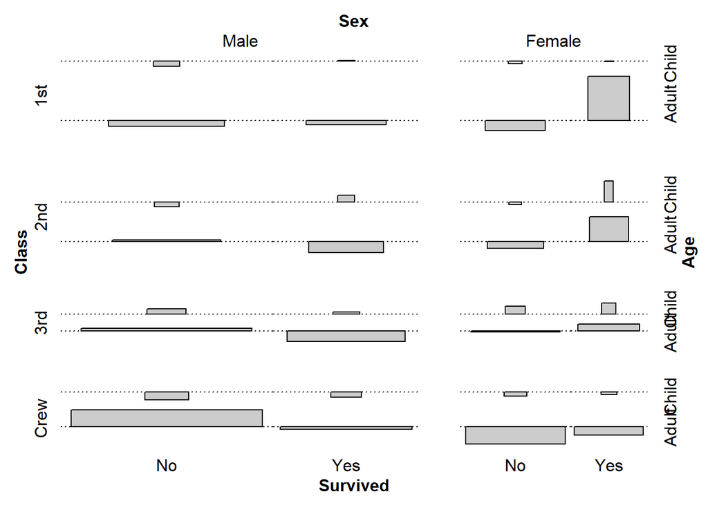

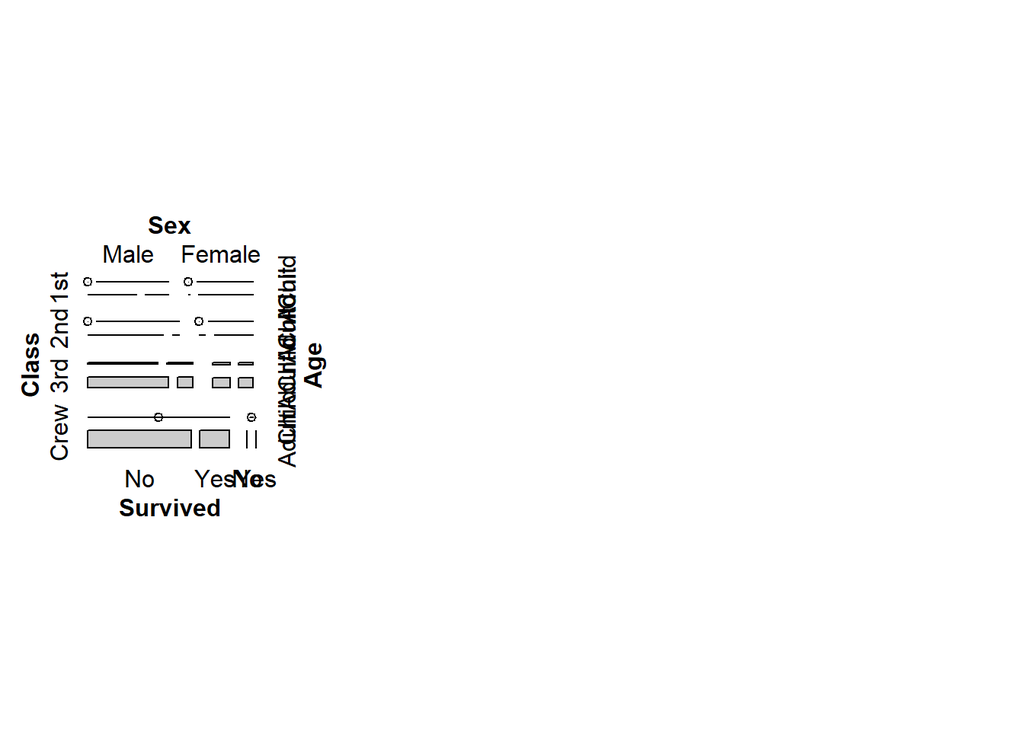

```r
mplot(mosaic(Titanic, return_grob = TRUE),
assoc(Titanic), return_grob = TRUE)
```

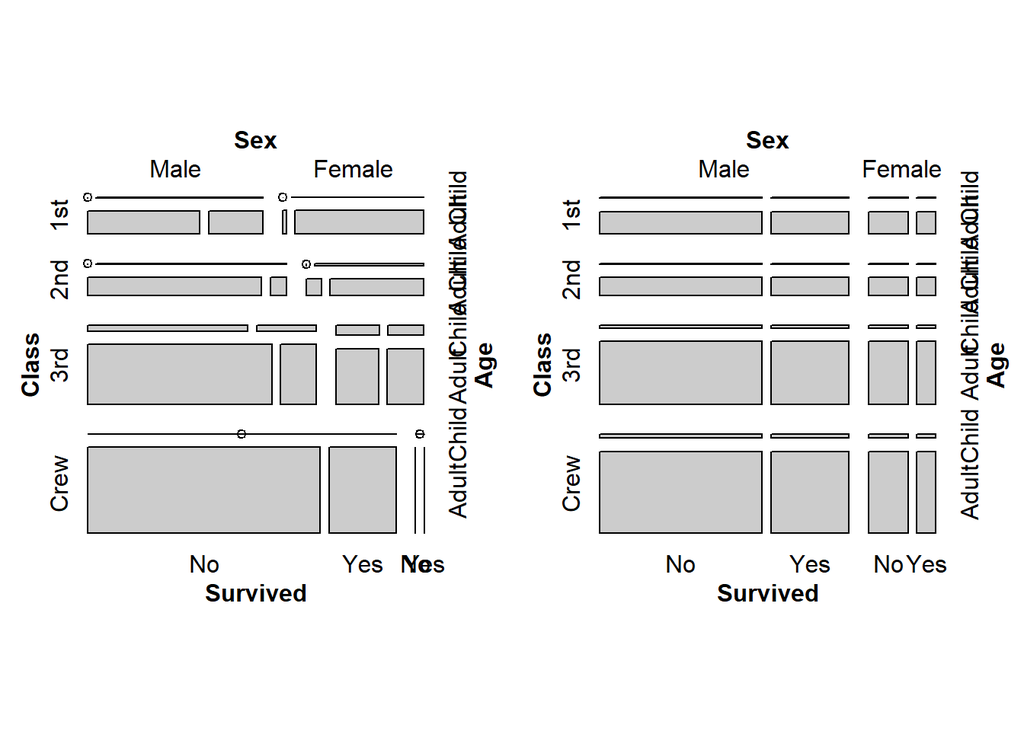

```r
A = mosaic(Titanic, return_grob = TRUE)
B = mosaic(Titanic, type = "expected", return_grob = TRUE)
mplot(A, B)
```

[figure not shown]

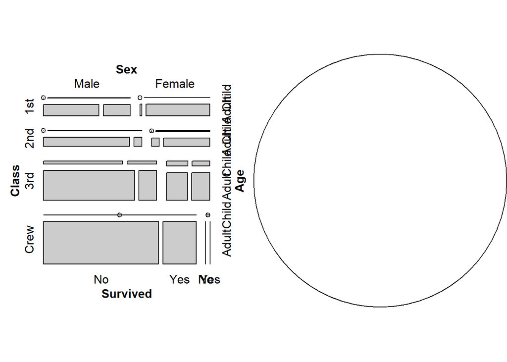

```r
mplot(sieve(SexualFun, return_grob = TRUE),
agreementplot(SexualFun, return_grob = TRUE),
main = "Sexual Fun")
mplot(A, grid.circle())
```

mplot Multiple Grid plots

#### Desription

combines severals grid-based plots in a multi-panel-layout.

#### Usage

```
mplot(..., .list = list(),
layout = NULL, cex = NULL,
main = NULL, gp_main = gpar(fontsize = 20),
sub = NULL, gp_sub = gpar(fontsize = 15),
keep_aspect_ratio = TRUE)
```

#### Examples

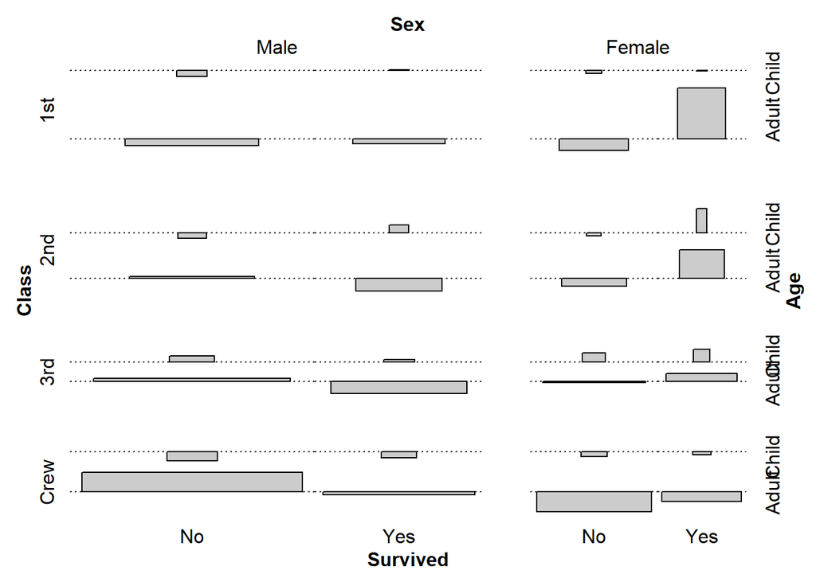

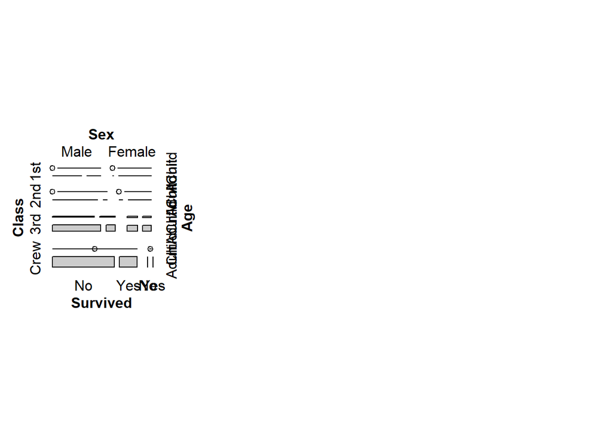

```r
mplot(mosaic(Titanic, return_grob = TRUE),
assoc(Titanic), return_grob = TRUE)
```

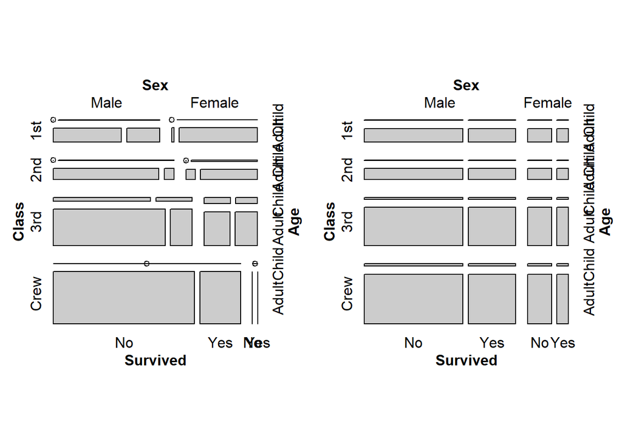

```r
A = mosaic(Titanic, return_grob = TRUE)
B = mosaic(Titanic, type = "expected", return_grob = TRUE)
mplot(A, B)
```

[figure not shown]

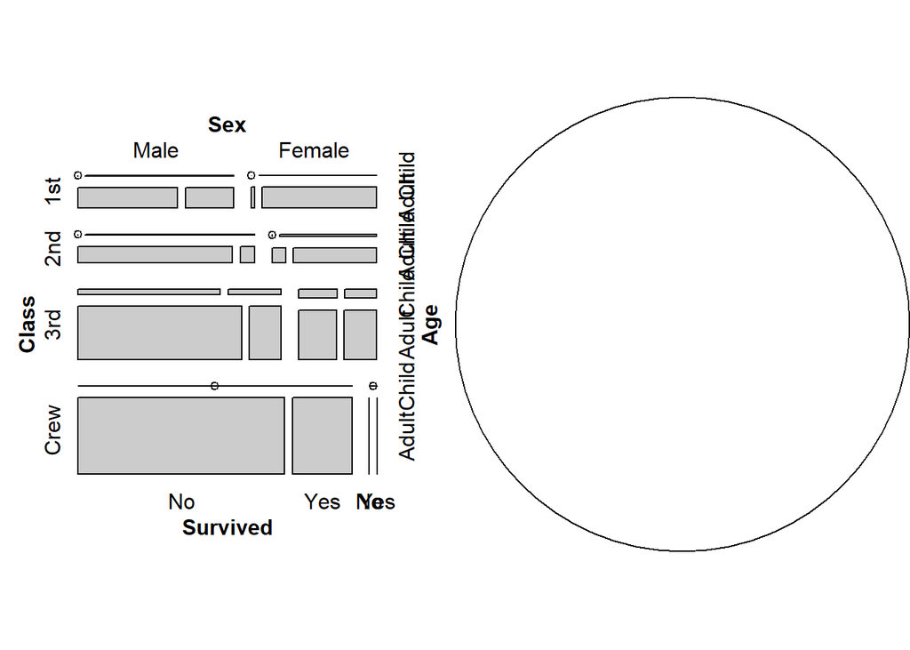

```r
mplot(sieve(SexualFun, return_grob = TRUE),
agreementplot(SexualFun, return_grob = TRUE),
main = "Sexual Fun")
mplot(A, grid.circle())
```

Details This is a convenience function for producing multi-panel plots from grid-based displays, especially those produced by the vcd methods. The layout (number of rows and columns) is guessed from the amount of supplied objects, if not supplied. Currently, the vcd plotting functions do not return grob objects by default-this might change in the future. Also, some of them will return the grob object as a "grob" attribute, attached to the currently returned object. Value None. Author(s) David Meyer David.Meyer@R-project.org